# Hierarchical Edge Bundling

- Show All Code
- Hide All Code
- View Source

Author

Théophile L. Mouton

Published

July 22, 2024

Constructing Hierarchical Edge Bundling charts for molecular data. One for females, the other for males.

# Molecular analytes

## Female data

### Load required libraries, data and create the dendrogram

This code loads necessary R packages, loads the female data, standardizes the data to one unit variance across sampled groups, calculates euclidean distances, performs hierarchical clustering and creates a dendrogram.

```r
# Load required libraries
library(readxl)
library(dplyr)
library(stats)
library(ggplot2)
library(ggdendro)
library(igraph)
library(ggraph)
library(tidygraph)

# Step 1: Load and standardize the data
data <- read_excel(here::here("Data/Mol_raw_data.xlsx"), sheet = 1)
data <- as.data.frame(data)

# Ensure the first column becomes the row names
rownames(data) <- data[,1]
data <- data[,-1]

#Standardise the data
scaled_data <- vegan::decostand(data, method="standardize", MARGIN = 1)

# Step 2: Calculate Euclidean distances
dist_matrix <- dist(scaled_data, method = "euclidean")

# Step 3: Apply hierarchical clustering
hc <- hclust(dist_matrix, method = "ward.D2")

# Step 4 : Convert to dendrogram
dendro <- as.dendrogram(hc)
```

### Create dataframes

This code creates three dataframes necessary for plotting the charts: edges, vertices and connections

```r
#Step 5: Use ggraph
hierarchy_graph = as_tbl_graph(dendro)

#Hierarchal dataframe
edge_df <- hierarchy_graph %>%
  activate(edges) %>%
  as_tibble() %>%
  rename(from = from, to = to)

# Extract vertices dataframe
vertex_df <- hierarchy_graph %>%
  activate(nodes) %>%
  as_tibble() %>%
  mutate(node_id = row_number())

vertices_my <- vertex_df %>%
  mutate(id = row_number(),
         name = label,
         shortName = label,  # Assuming you don't have a shorter name
         group = ifelse(leaf, "leaf", "internal")) %>%
  select(id, name, shortName, group, leaf, height, members) %>%
  arrange(name) %>%
  mutate(name = factor(name, levels = unique(name)))

# Check for NA or empty names and replace them with a placeholder
vertices_my <- vertices_my %>%
  mutate(shortName = ifelse(is.na(shortName) | shortName == "", paste0("Node", row_number()), shortName)) %>%
  mutate(name = ifelse(is.na(name) | name == "", paste0("Node_", row_number()), name))

# Create connections_my dataframe
connections_my_df <- edge_df %>%
  left_join(vertex_df, by = c("from" = "node_id")) %>%
  left_join(vertex_df, by = c("to" = "node_id"), suffix = c("_from", "_to"))

connections_my <- connections_my_df %>%
  select(from, to) %>% #This selects only the 'from' and 'to' columns from the original dataframe.
  mutate(from = vertices_my$name[from],
         to = vertices_my$name[to]) %>% #This replaces the values in the 'from' and 'to' columns with corresponding names from the vertices_my dataframe.
  distinct() #This removes any duplicate rows from the resulting dataframe.

connections_my <- connections_my %>%
  filter(from != "" & to != "") #This keeps only the rows where from and to are not empty strings

# Preparation to draw labels properly:
# Extract vertex data
vertices_my <- hierarchy_graph %>%
  activate(nodes) %>%
  as_tibble() %>%
  mutate(
    id = row_number(),
    name = label,
    shortName = label,  # Keep original labels
    group = ifelse(leaf, "leaf", "internal"),
    unique_name = make.unique(as.character(name), sep = "_")
  ) %>%
  select(id, name, shortName, unique_name, group, leaf, height, members)

# Correct any empty or NA names only for internal nodes
vertices_my <- vertices_my %>%
  mutate(
    name = ifelse(!leaf & (is.na(name) | name == ""), paste0("Node_", row_number()), name),
    shortName = ifelse(!leaf & (is.na(shortName) | shortName == ""), paste0("Node", row_number()), shortName)
  )

# Prepare label angles for leaves
leaf_vertices <- vertices_my %>%
  filter(leaf) %>%
  mutate(
    leaf_id = row_number(),
    angle = 90 - 360 * (leaf_id - 1) / n(),
    hjust = ifelse(angle < -90, 1, 0),
    angle = ifelse(angle < -90, angle + 180, angle)
  )

# Update vertices_my with leaf angles
vertices_my <- vertices_my %>%
  left_join(leaf_vertices %>% select(id, angle, hjust), by = "id")
```

### The circular dendrogram

This code plots a circular dendrogram from the hierarchical clustering results

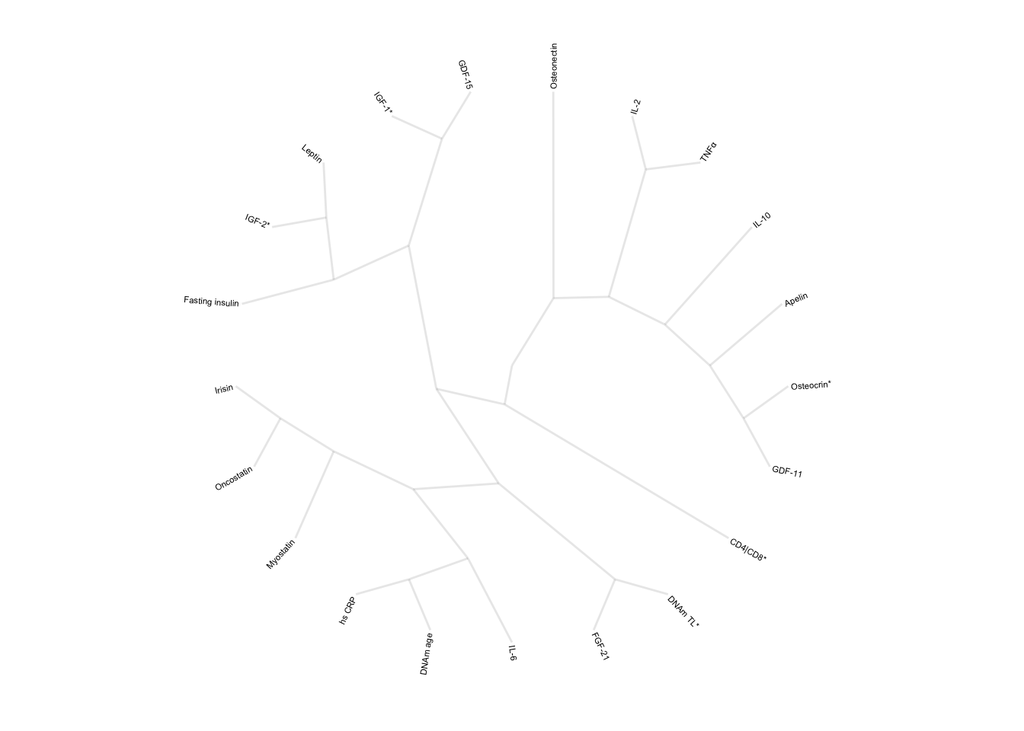

```r
#Create the graph object
mygraph <- graph_from_data_frame(edge_df, vertices = vertices_my)

# Basic dendrogram ----
ggraph(mygraph, layout = 'dendrogram', circular = TRUE) +
  geom_edge_link(size = 0.4, alpha = 0.1) +
  geom_node_text(aes(x = x*1.01, y = y*1.01, filter = leaf, label = shortName, angle = angle, hjust = hjust), size = 1.5, alpha = 1) +
  coord_fixed() +
  theme_void() +
  theme(
    legend.position = "none",
    plot.margin = unit(c(0,0,0,0),"cm"),
  ) +
  expand_limits(x = c(-1.2, 1.2), y = c(-1.2, 1.2))
```

### The hierarchical edge bundling

This code plots a hierarchical edge bundling chart from the hierarchy defined in the dendrogram

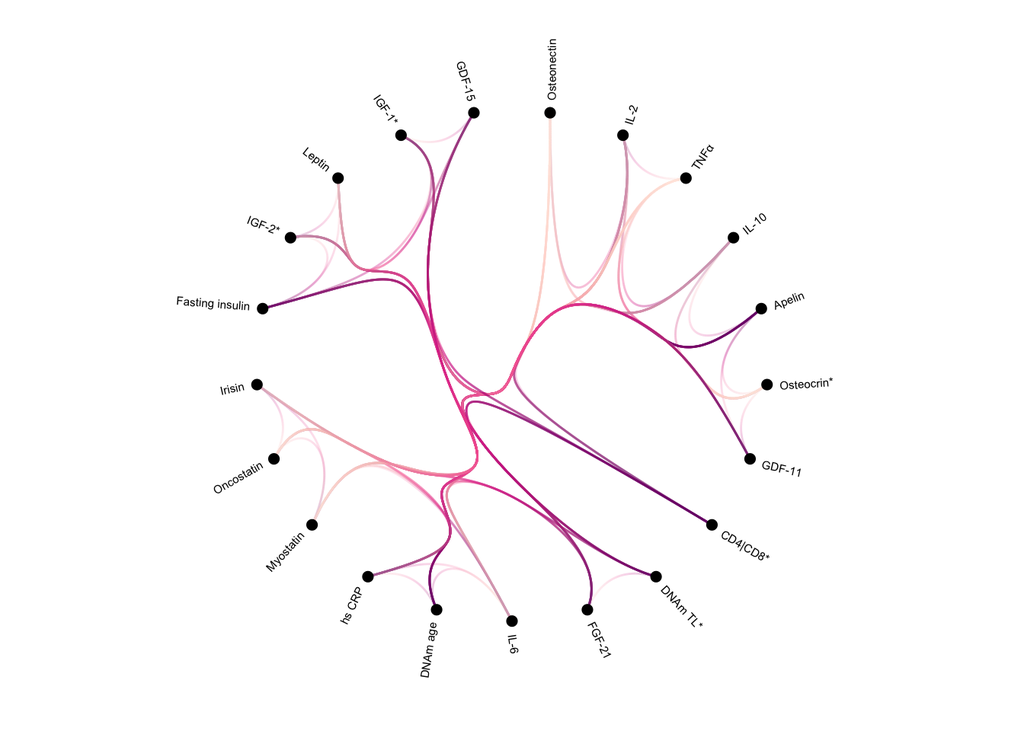

```r
#Correct the connections_my dataframe with valid connections
# Get leaf nodes
leaf_nodes <- V(mygraph)$name[V(mygraph)$leaf]

# Create all possible combinations of leaf nodes
all_combinations <- expand.grid(from = leaf_nodes, to = leaf_nodes) %>%
  mutate(
    from = as.character(from),
    to = as.character(to)
  )

# Remove self-connections and duplicate connections
connections_my_corrected <- all_combinations %>%
  filter(from != to) %>%  # Remove self-connections
  mutate(
    pair = pmin(from, to),
    pair_to = pmax(from, to)
  ) %>%
  distinct(pair, pair_to) %>%  # Remove duplicates
  select(from = pair, to = pair_to)

# Convert node names to indices
from <- match(connections_my_corrected$from, V(mygraph)$name)
to <- match(connections_my_corrected$to, V(mygraph)$name)

# Plot the hierarchical edge bundle
ggraph(mygraph, layout = 'dendrogram', circular = TRUE) +
  geom_conn_bundle(data = get_con(from = from, to = to),
                   alpha = 0.2,  # Reduced alpha for better visibility
                 #  colour="#69b3a2",
                   tension = 1.5,
  aes(colour=after_stat(index))) +
  scale_edge_colour_distiller(palette = "RdPu") +
  geom_node_point(aes(filter = leaf), size = 2, color = "black") +
  geom_node_text(aes(x = x*1.05, y=y*1.05, filter = leaf, label=shortName, angle = angle, hjust=hjust),
                 size=2, alpha=1) +
  coord_fixed() +
  theme_void() +
  theme(
    legend.position="none",
    plot.margin=unit(c(0,0,0,0),"cm"),
  ) +
  expand_limits(x = c(-1.3, 1.3), y = c(-1.3, 1.3))
```

## Male data

### Load data and create the dendrogram

This code loads the male data, standardizes the data to one unit variance across sampled groups, calculates euclidean distances, performs hierarchical clustering and creates a dendrogram.

```r
# Step 1: Load and standardize the data
data <- read_excel(here::here("Data/Mol_raw_data.xlsx"), sheet = 2)
data <- as.data.frame(data)

# Ensure the first column becomes the row names
rownames(data) <- data[,1]
data <- data[,-1]

#Standardise the data
scaled_data <- vegan::decostand(data, method="standardize", MARGIN = 1)

# Step 2: Calculate Euclidean distances
dist_matrix <- dist(scaled_data, method = "euclidean")

# Step 3: Apply hierarchical clustering
hc <- hclust(dist_matrix, method = "ward.D2")

# Step 4 : Convert to dendrogram
dendro <- as.dendrogram(hc)
```

### Create dataframes

This code creates three dataframes necessary for plotting the charts: edges, vertices and connections

```r
#Step 5: Use ggraph
hierarchy_graph = as_tbl_graph(dendro)

#Hierarchal dataframe
edge_df <- hierarchy_graph %>%
  activate(edges) %>%
  as_tibble() %>%
  rename(from = from, to = to)

# Extract vertices dataframe
vertex_df <- hierarchy_graph %>%
  activate(nodes) %>%
  as_tibble() %>%
  mutate(node_id = row_number())

vertices_my <- vertex_df %>%
  mutate(id = row_number(),
         name = label,
         shortName = label,  # Assuming you don't have a shorter name
         group = ifelse(leaf, "leaf", "internal")) %>%
  select(id, name, shortName, group, leaf, height, members) %>%
  arrange(name) %>%
  mutate(name = factor(name, levels = unique(name)))

# Check for NA or empty names and replace them with a placeholder
vertices_my <- vertices_my %>%
  mutate(shortName = ifelse(is.na(shortName) | shortName == "", paste0("Node", row_number()), shortName)) %>%
  mutate(name = ifelse(is.na(name) | name == "", paste0("Node_", row_number()), name))

# Create connections_my dataframe
connections_my_df <- edge_df %>%
  left_join(vertex_df, by = c("from" = "node_id")) %>%
  left_join(vertex_df, by = c("to" = "node_id"), suffix = c("_from", "_to"))

connections_my <- connections_my_df %>%
  select(from, to) %>% #This selects only the 'from' and 'to' columns from the original dataframe.
  mutate(from = vertices_my$name[from],
         to = vertices_my$name[to]) %>% #This replaces the values in the 'from' and 'to' columns with corresponding names from the vertices_my dataframe.
  distinct() #This removes any duplicate rows from the resulting dataframe.

connections_my <- connections_my %>%
  filter(from != "" & to != "") #This keeps only the rows where from and to are not empty strings

# Preparation to draw labels properly:
# Extract vertex data
vertices_my <- hierarchy_graph %>%
  activate(nodes) %>%
  as_tibble() %>%
  mutate(
    id = row_number(),
    name = label,
    shortName = label,  # Keep original labels
    group = ifelse(leaf, "leaf", "internal"),
    unique_name = make.unique(as.character(name), sep = "_")
  ) %>%
  select(id, name, shortName, unique_name, group, leaf, height, members)

# Correct any empty or NA names only for internal nodes
vertices_my <- vertices_my %>%
  mutate(
    name = ifelse(!leaf & (is.na(name) | name == ""), paste0("Node_", row_number()), name),
    shortName = ifelse(!leaf & (is.na(shortName) | shortName == ""), paste0("Node", row_number()), shortName)
  )

# Prepare label angles for leaves
leaf_vertices <- vertices_my %>%
  filter(leaf) %>%
  mutate(
    leaf_id = row_number(),
    angle = 90 - 360 * (leaf_id - 1) / n(),
    hjust = ifelse(angle < -90, 1, 0),
    angle = ifelse(angle < -90, angle + 180, angle)
  )

# Update vertices_my with leaf angles
vertices_my <- vertices_my %>%
  left_join(leaf_vertices %>% select(id, angle, hjust), by = "id")
```

### The circular dendrogram

This code plots a circular dendrogram from the hierarchical clustering results

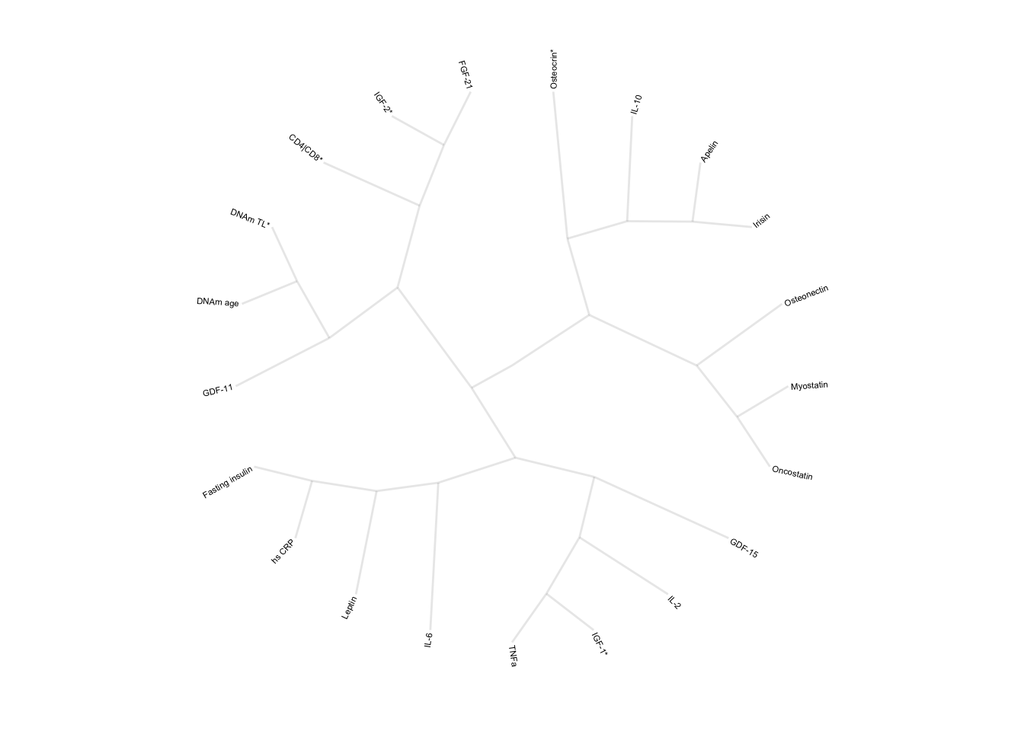

```r
#Create the graph object
mygraph <- graph_from_data_frame(edge_df, vertices = vertices_my)

# Basic dendrogram ----
ggraph(mygraph, layout = 'dendrogram', circular = TRUE) +
  geom_edge_link(size = 0.4, alpha = 0.1) +
  geom_node_text(aes(x = x*1.01, y = y*1.01, filter = leaf, label = shortName, angle = angle, hjust = hjust), size = 1.5, alpha = 1) +
  coord_fixed() +
  theme_void() +
  theme(
    legend.position = "none",
    plot.margin = unit(c(0,0,0,0),"cm"),
  ) +
  expand_limits(x = c(-1.2, 1.2), y = c(-1.2, 1.2))
```

### The hierarchical edge bundling

This code plots a hierarchical edge bundling chart from the hierarchy defined in the dendrogram

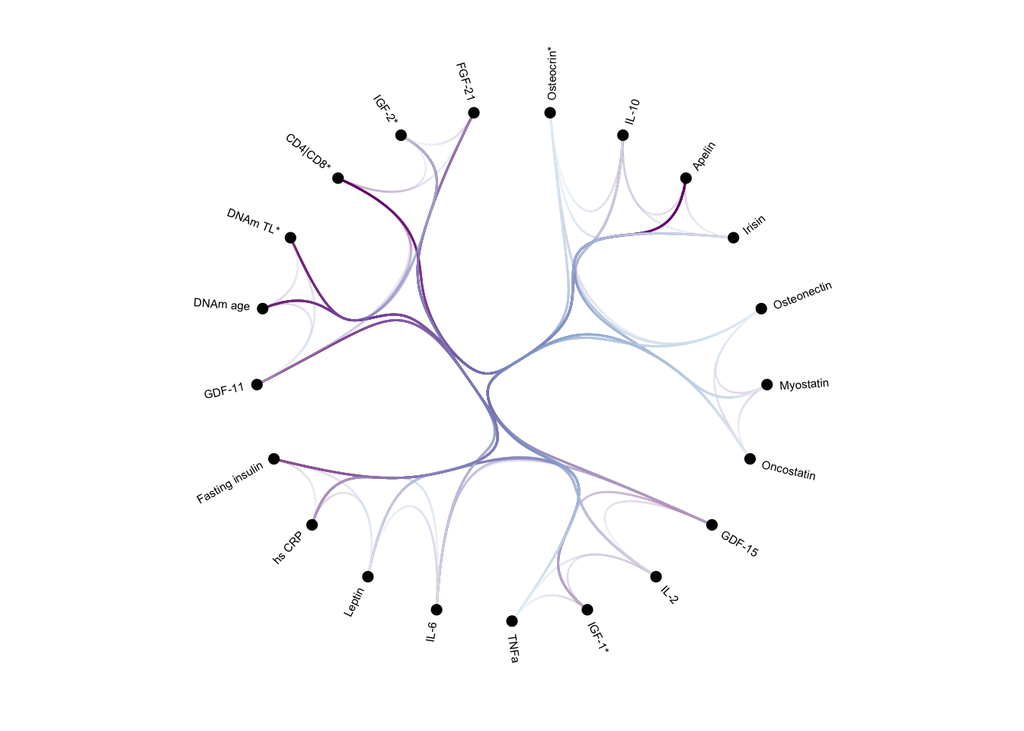

```r
#Correct the connections_my dataframe with valid connections
# Get leaf nodes
leaf_nodes <- V(mygraph)$name[V(mygraph)$leaf]

# Create all possible combinations of leaf nodes
all_combinations <- expand.grid(from = leaf_nodes, to = leaf_nodes) %>%
  mutate(
    from = as.character(from),
    to = as.character(to)
  )

# Remove self-connections and duplicate connections
connections_my_corrected <- all_combinations %>%
  filter(from != to) %>%  # Remove self-connections
  mutate(
    pair = pmin(from, to),
    pair_to = pmax(from, to)
  ) %>%
  distinct(pair, pair_to) %>%  # Remove duplicates
  select(from = pair, to = pair_to)

# Convert node names to indices
from <- match(connections_my_corrected$from, V(mygraph)$name)
to <- match(connections_my_corrected$to, V(mygraph)$name)

# Plot the hierarchical edge bundle
ggraph(mygraph, layout = 'dendrogram', circular = TRUE) +
  geom_conn_bundle(data = get_con(from = from, to = to),
                   alpha = 0.2,  # Reduced alpha for better visibility
                 #  colour="#69b3a2",
                   tension = 1.5,
  aes(colour=after_stat(index))) +
  scale_edge_colour_distiller(palette = "BuPu") +
  geom_node_point(aes(filter = leaf), size = 2, color = "black") +
  geom_node_text(aes(x = x*1.05, y=y*1.05, filter = leaf, label=shortName, angle = angle, hjust=hjust),
                 size=2, alpha=1) +
  coord_fixed() +
  theme_void() +
  theme(
    legend.position="none",
    plot.margin=unit(c(0,0,0,0),"cm"),
  ) +
  expand_limits(x = c(-1.3, 1.3), y = c(-1.3, 1.3))
```

# Molecular analytes and cardiometabolic health markers

## Female data

### Load data and create the dendrogram

```r
# Step 1: Load and standardize the data
data <- read_excel(here::here("Data/Mol_raw_data.xlsx"), sheet = 3)
data <- as.data.frame(data)

# Ensure the first column becomes the row names
rownames(data) <- data[,1]
data <- data[,-1]

#Standardise the data
scaled_data <- vegan::decostand(data, method="standardize", MARGIN = 1)

# Step 2: Calculate Euclidean distances
dist_matrix <- dist(scaled_data, method = "euclidean")

# Step 3: Apply hierarchical clustering
hc <- hclust(dist_matrix, method = "ward.D2")

# Step 4 : Convert to dendrogram
dendro <- as.dendrogram(hc)
```

### Create dataframes

This code creates three dataframes necessary for plotting the charts: edges, vertices and connections

```r
#Step 5: Use ggraph
hierarchy_graph = as_tbl_graph(dendro)

#Hierarchal dataframe
edge_df <- hierarchy_graph %>%
  activate(edges) %>%
  as_tibble() %>%
  rename(from = from, to = to)

# Extract vertices dataframe
vertex_df <- hierarchy_graph %>%
  activate(nodes) %>%
  as_tibble() %>%
  mutate(node_id = row_number())

vertices_my <- vertex_df %>%
  mutate(id = row_number(),
         name = label,
         shortName = label,  # Assuming you don't have a shorter name
         group = ifelse(leaf, "leaf", "internal")) %>%
  select(id, name, shortName, group, leaf, height, members) %>%
  arrange(name) %>%
  mutate(name = factor(name, levels = unique(name)))

# Check for NA or empty names and replace them with a placeholder
vertices_my <- vertices_my %>%
  mutate(shortName = ifelse(is.na(shortName) | shortName == "", paste0("Node", row_number()), shortName)) %>%
  mutate(name = ifelse(is.na(name) | name == "", paste0("Node_", row_number()), name))

# Create connections_my dataframe
connections_my_df <- edge_df %>%
  left_join(vertex_df, by = c("from" = "node_id")) %>%
  left_join(vertex_df, by = c("to" = "node_id"), suffix = c("_from", "_to"))

connections_my <- connections_my_df %>%
  select(from, to) %>% #This selects only the 'from' and 'to' columns from the original dataframe.
  mutate(from = vertices_my$name[from],
         to = vertices_my$name[to]) %>% #This replaces the values in the 'from' and 'to' columns with corresponding names from the vertices_my dataframe.
  distinct() #This removes any duplicate rows from the resulting dataframe.

connections_my <- connections_my %>%
  filter(from != "" & to != "") #This keeps only the rows where from and to are not empty strings

# Preparation to draw labels properly:
# Extract vertex data
vertices_my <- hierarchy_graph %>%
  activate(nodes) %>%
  as_tibble() %>%
  mutate(
    id = row_number(),
    name = label,
    shortName = label,  # Keep original labels
    group = ifelse(leaf, "leaf", "internal"),
    unique_name = make.unique(as.character(name), sep = "_")
  ) %>%
  select(id, name, shortName, unique_name, group, leaf, height, members)

# Correct any empty or NA names only for internal nodes
vertices_my <- vertices_my %>%
  mutate(
    name = ifelse(!leaf & (is.na(name) | name == ""), paste0("Node_", row_number()), name),
    shortName = ifelse(!leaf & (is.na(shortName) | shortName == ""), paste0("Node", row_number()), shortName)
  )

# Prepare label angles for leaves
leaf_vertices <- vertices_my %>%
  filter(leaf) %>%
  mutate(
    leaf_id = row_number(),
    angle = 90 - 360 * (leaf_id - 1) / n(),
    hjust = ifelse(angle < -90, 1, 0),
    angle = ifelse(angle < -90, angle + 180, angle)
  )

# Update vertices_my with leaf angles
vertices_my <- vertices_my %>%
  left_join(leaf_vertices %>% select(id, angle, hjust), by = "id")
```

### The circular dendrogram

This code plots a circular dendrogram from the hierarchical clustering results

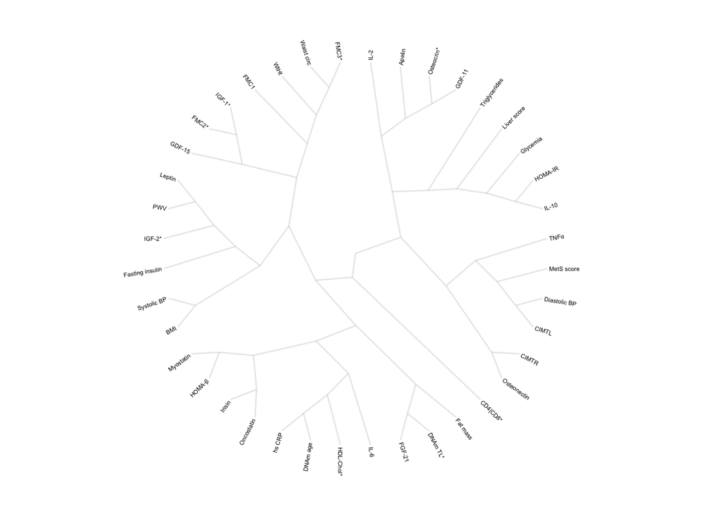

```r
#Create the graph object
mygraph <- graph_from_data_frame(edge_df, vertices = vertices_my)

# Basic dendrogram ----
ggraph(mygraph, layout = 'dendrogram', circular = TRUE) +
  geom_edge_link(size = 0.4, alpha = 0.1) +
  geom_node_text(aes(x = x*1.01, y = y*1.01, filter = leaf, label = shortName, angle = angle, hjust = hjust), size = 1.5, alpha = 1) +
  coord_fixed() +
  theme_void() +
  theme(
    legend.position = "none",
    plot.margin = unit(c(0,0,0,0),"cm"),
  ) +
  expand_limits(x = c(-1.2, 1.2), y = c(-1.2, 1.2))
```

### The hierarchical edge bundling

This code plots a hierarchical edge bundling chart from the hierarchy defined in the dendrogram

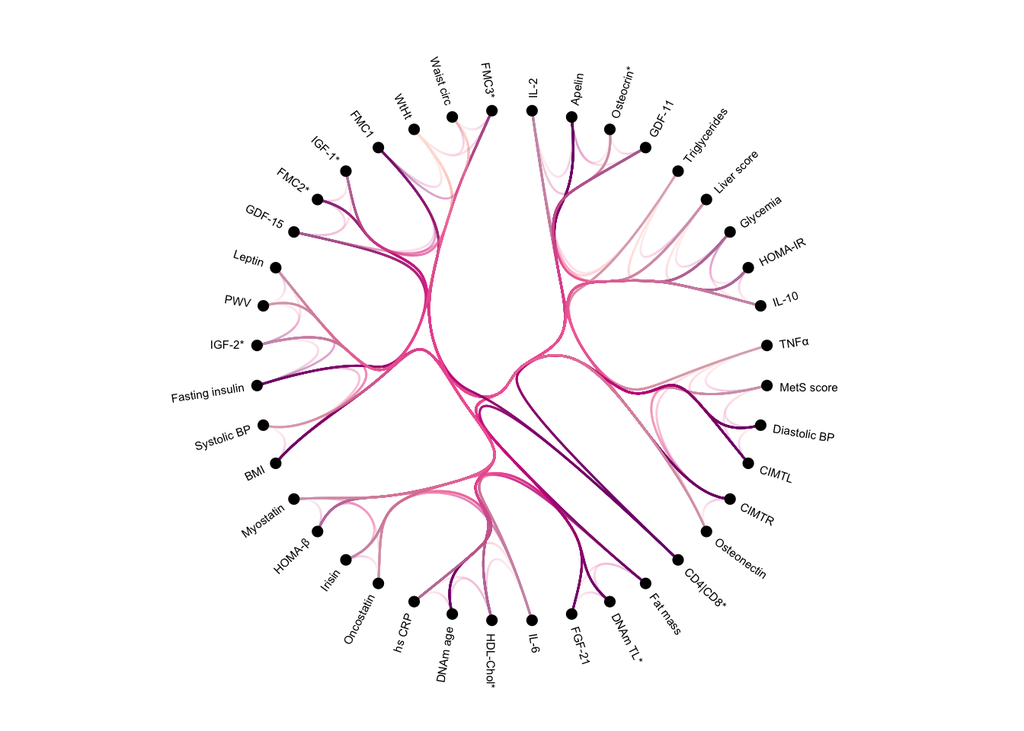

```r
#Correct the connections_my dataframe with valid connections
# Get leaf nodes
leaf_nodes <- V(mygraph)$name[V(mygraph)$leaf]

# Create all possible combinations of leaf nodes
all_combinations <- expand.grid(from = leaf_nodes, to = leaf_nodes) %>%
  mutate(
    from = as.character(from),
    to = as.character(to)
  )

# Remove self-connections and duplicate connections
connections_my_corrected <- all_combinations %>%
  filter(from != to) %>%  # Remove self-connections
  mutate(
    pair = pmin(from, to),
    pair_to = pmax(from, to)
  ) %>%
  distinct(pair, pair_to) %>%  # Remove duplicates
  select(from = pair, to = pair_to)

# Convert node names to indices
from <- match(connections_my_corrected$from, V(mygraph)$name)
to <- match(connections_my_corrected$to, V(mygraph)$name)

# Plot the hierarchical edge bundle
ggraph(mygraph, layout = 'dendrogram', circular = TRUE) +
  geom_conn_bundle(data = get_con(from = from, to = to),
                   alpha = 0.2,  # Reduced alpha for better visibility
                 #  colour="#69b3a2",
                   tension = 1.5,
  aes(colour=after_stat(index))) +
  scale_edge_colour_distiller(palette = "RdPu") +
  geom_node_point(aes(filter = leaf), size = 2, color = "black") +
  geom_node_text(aes(x = x*1.05, y=y*1.05, filter = leaf, label=shortName, angle = angle, hjust=hjust),
                 size=2, alpha=1) +
  coord_fixed() +
  theme_void() +
  theme(
    legend.position="none",
    plot.margin=unit(c(0,0,0,0),"cm"),
  ) +
  expand_limits(x = c(-1.3, 1.3), y = c(-1.3, 1.3))
```

## Male data

### Load data and create the dendrogram

This code loads the male data, standardizes the data to one unit variance across sampled groups, calculates euclidean distances, performs hierarchical clustering and creates a dendrogram.

```r
# Step 1: Load and standardize the data
data <- read_excel(here::here("Data/Mol_raw_data.xlsx"), sheet = 4)
data <- as.data.frame(data)

# Ensure the first column becomes the row names
rownames(data) <- data[,1]
data <- data[,-1]

#Standardise the data
scaled_data <- vegan::decostand(data, method="standardize", MARGIN = 1)

# Step 2: Calculate Euclidean distances
dist_matrix <- dist(scaled_data, method = "euclidean")

# Step 3: Apply hierarchical clustering
hc <- hclust(dist_matrix, method = "ward.D2")

# Step 4 : Convert to dendrogram
dendro <- as.dendrogram(hc)
```

### Create dataframes

This code creates three dataframes necessary for plotting the charts: edges, vertices and connections

```r
#Step 5: Use ggraph
hierarchy_graph = as_tbl_graph(dendro)

#Hierarchal dataframe
edge_df <- hierarchy_graph %>%
  activate(edges) %>%
  as_tibble() %>%
  rename(from = from, to = to)

# Extract vertices dataframe
vertex_df <- hierarchy_graph %>%
  activate(nodes) %>%
  as_tibble() %>%
  mutate(node_id = row_number())

vertices_my <- vertex_df %>%
  mutate(id = row_number(),
         name = label,
         shortName = label,  # Assuming you don't have a shorter name
         group = ifelse(leaf, "leaf", "internal")) %>%
  select(id, name, shortName, group, leaf, height, members) %>%
  arrange(name) %>%
  mutate(name = factor(name, levels = unique(name)))

# Check for NA or empty names and replace them with a placeholder
vertices_my <- vertices_my %>%
  mutate(shortName = ifelse(is.na(shortName) | shortName == "", paste0("Node", row_number()), shortName)) %>%
  mutate(name = ifelse(is.na(name) | name == "", paste0("Node_", row_number()), name))

# Create connections_my dataframe
connections_my_df <- edge_df %>%
  left_join(vertex_df, by = c("from" = "node_id")) %>%
  left_join(vertex_df, by = c("to" = "node_id"), suffix = c("_from", "_to"))

connections_my <- connections_my_df %>%
  select(from, to) %>% #This selects only the 'from' and 'to' columns from the original dataframe.
  mutate(from = vertices_my$name[from],
         to = vertices_my$name[to]) %>% #This replaces the values in the 'from' and 'to' columns with corresponding names from the vertices_my dataframe.
  distinct() #This removes any duplicate rows from the resulting dataframe.

connections_my <- connections_my %>%
  filter(from != "" & to != "") #This keeps only the rows where from and to are not empty strings

# Preparation to draw labels properly:
# Extract vertex data
vertices_my <- hierarchy_graph %>%
  activate(nodes) %>%
  as_tibble() %>%
  mutate(
    id = row_number(),
    name = label,
    shortName = label,  # Keep original labels
    group = ifelse(leaf, "leaf", "internal"),
    unique_name = make.unique(as.character(name), sep = "_")
  ) %>%
  select(id, name, shortName, unique_name, group, leaf, height, members)

# Correct any empty or NA names only for internal nodes
vertices_my <- vertices_my %>%
  mutate(
    name = ifelse(!leaf & (is.na(name) | name == ""), paste0("Node_", row_number()), name),
    shortName = ifelse(!leaf & (is.na(shortName) | shortName == ""), paste0("Node", row_number()), shortName)
  )

# Prepare label angles for leaves
leaf_vertices <- vertices_my %>%
  filter(leaf) %>%
  mutate(
    leaf_id = row_number(),
    angle = 90 - 360 * (leaf_id - 1) / n(),
    hjust = ifelse(angle < -90, 1, 0),
    angle = ifelse(angle < -90, angle + 180, angle)
  )

# Update vertices_my with leaf angles
vertices_my <- vertices_my %>%
  left_join(leaf_vertices %>% select(id, angle, hjust), by = "id")
```

### The circular dendrogram

This code plots a circular dendrogram from the hierarchical clustering results

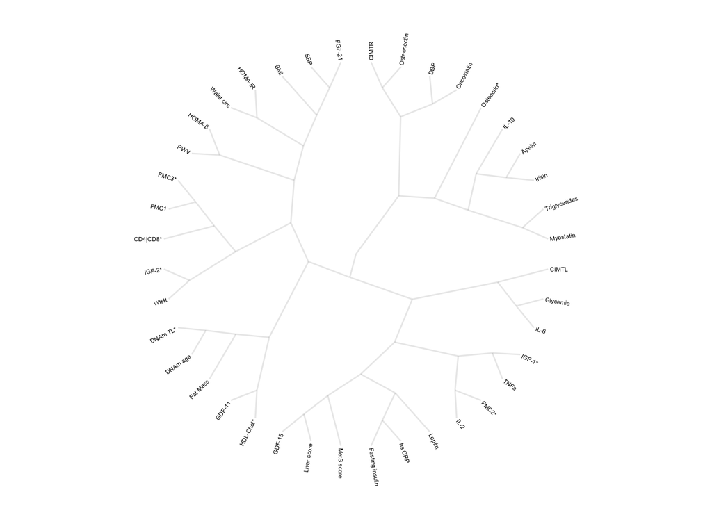

```r
#Create the graph object
mygraph <- graph_from_data_frame(edge_df, vertices = vertices_my)

# Basic dendrogram ----
ggraph(mygraph, layout = 'dendrogram', circular = TRUE) +
  geom_edge_link(size = 0.4, alpha = 0.1) +
  geom_node_text(aes(x = x*1.01, y = y*1.01, filter = leaf, label = shortName, angle = angle, hjust = hjust), size = 1.5, alpha = 1) +
  coord_fixed() +
  theme_void() +
  theme(
    legend.position = "none",
    plot.margin = unit(c(0,0,0,0),"cm"),
  ) +
  expand_limits(x = c(-1.2, 1.2), y = c(-1.2, 1.2))
```

### The hierarchical edge bundling

This code plots a hierarchical edge bundling chart from the hierarchy defined in the dendrogram

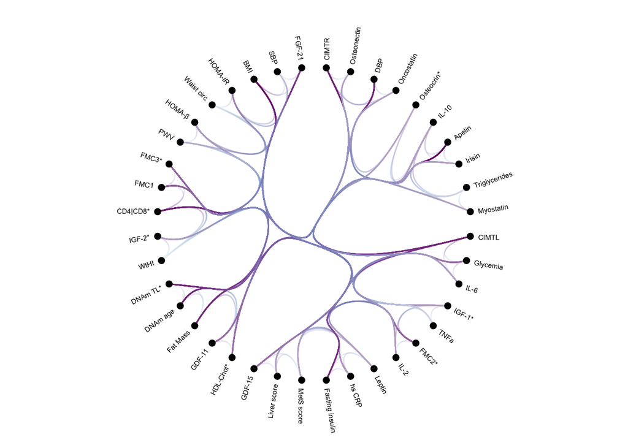

```r
#Correct the connections_my dataframe with valid connections
# Get leaf nodes
leaf_nodes <- V(mygraph)$name[V(mygraph)$leaf]

# Create all possible combinations of leaf nodes
all_combinations <- expand.grid(from = leaf_nodes, to = leaf_nodes) %>%
  mutate(
    from = as.character(from),
    to = as.character(to)
  )

# Remove self-connections and duplicate connections
connections_my_corrected <- all_combinations %>%
  filter(from != to) %>%  # Remove self-connections
  mutate(
    pair = pmin(from, to),
    pair_to = pmax(from, to)
  ) %>%
  distinct(pair, pair_to) %>%  # Remove duplicates
  select(from = pair, to = pair_to)

# Convert node names to indices
from <- match(connections_my_corrected$from, V(mygraph)$name)
to <- match(connections_my_corrected$to, V(mygraph)$name)

# Plot the hierarchical edge bundle
ggraph(mygraph, layout = 'dendrogram', circular = TRUE) +
  geom_conn_bundle(data = get_con(from = from, to = to),
                   alpha = 0.2,  # Reduced alpha for better visibility
                 #  colour="#69b3a2",
                   tension = 1.5,
  aes(colour=after_stat(index))) +
  scale_edge_colour_distiller(palette = "BuPu") +
  geom_node_point(aes(filter = leaf), size = 2, color = "black") +
  geom_node_text(aes(x = x*1.05, y=y*1.05, filter = leaf, label=shortName, angle = angle, hjust=hjust),
                 size=2, alpha=1) +
  coord_fixed() +
  theme_void() +
  theme(
    legend.position="none",
    plot.margin=unit(c(0,0,0,0),"cm"),
  ) +
  expand_limits(x = c(-1.3, 1.3), y = c(-1.3, 1.3))
```